# ST 431/531: Sampling Methods

Two Stage Cluster Sampling | Systematic Sampling

Week 6

# Lecture 1

## Outline

- Introduction
- Estimators and SE
  - Unbiased estimator
  - Ratio Estimator
- Example: *Lohr* 5.8.7
- Sampling Weights

## Review

In a **one-stage cluster sample**, we take a SRS of psus (clusters) and then observe every unit in those clusters.

This means that cluster means or totals are known *exactly* for the sampled clusters (they do not have to be estimated). We can use this one number (e.g., $t_i$ for cluster $i$) in the same SRS estimators we are used to from Chapter 2.

This works well when all the clusters are the same size.

When the clusters are different sizes, the $t_i$ vary a lot, so although we could also calculate the unbiased estimator, we may prefer the ratio estimator.

## Two-Stage Cluster Sampling

#### Procedure:

1. Select an SRS $\mathcal{S}$ of $n$ psus from the population of $N$ psus.
2. Select an SRS of ssus from each selected psu. The SRS of $m_i$ elements from the $i$th psu is denoted $\mathcal{S}_i$.

This extra stage of sampling complicates the notation and estimators, as we need to consider the variability arising from *both* stages of data collection.

## Unbiased Estimator Comparison

#### One-Stage:

$\hat{t}_\text{unb}=\frac{N}{n}\sum\limits_{i\in\mathcal{S}}t_i$

#### Two-Stage:

$\hat{t}_\text{unb}=\frac{N}{n}\sum\limits_{i\in\mathcal{S}}\hat{t}_i=\frac{N}{n}\sum\limits_{i\in\mathcal{S}}M_i\bar{y}_i$

## Exact Variance for Two-Stage Cluster Sampling Unbiased Estimator

Now, the $\hat{t}_i$’s are *random variables*, so the variance of $\hat{t}_\text{unb}$ has two components: the variability between psus and the variability of ssus within psus.

$$V(\hat{t}_\text{unb})=\underbrace{N^2\left(1-\frac{n}{N}\right)\frac{S_t^2}{n}}_{\text{variation due to stage 1 sampling}}+\underbrace{\frac{N}{n}\sum_{i=1}^N\left(1-\frac{m_i}{M_i}\right)M_i^2\frac{S_i^2}{m_i}}_{\text{variation due to stage 2 sampling}}$$

where $S_t^2$ is the population variance of the cluster totals and $S_i^2$ is the population variance among the elements within cluster $i$.

- In one-stage cluster sampling, the second term is 0 since $m_i=M_i$.
- If we sampled from every single cluster, the first term is 0 since $n=N$. What does this remind you of?

## Sample Variances for Different Stages

We need to estimate $s_t^2$ (sample variance among estimated psu totals) and $s_i^2$ (sample variance of the ssus sampled in psu $i$).

$$\begin{align*}
s_t^2 &= \frac{1}{n-1}\sum_{i\in\mathcal{S}}\left(\hat{t}_i-\frac{\hat{t}_\text{unb}}{N}\right)^2 \\
s_i^2 &= \frac{1}{m_i-1} \sum_{j\in\mathcal{S}_i}(y_{ij}-\bar{y}_i)^2 \\
\end{align*}$$

## Estimated Variance for Two-Stage Cluster Sampling Unbiased Estimator

An unbiased estimator of the variance of $\hat{t}_\text{unb}$ is then

$$\hat{V}(\hat{t}_\text{unb})=N^2\left(1-\frac{n}{N}\right)\frac{s_t^2}{n}+\frac{N}{n}\sum_{i\in\mathcal{S}}\left(1-\frac{m_i}{M_i}\right)M_i^2\frac{s_i^2}{m_i}$$

*Note*: in many cases, $N$ is very large, in which case the second term is negligible compared to the first term and the fpc $\approx$ 1, so

$$\hat{V}(\hat{t}_\text{unb}) \approx N^2\frac{s_t^2}{n} \qquad \text{large }N\text{ approximation}$$

Some software uses the large $N$ approximation, so you should be aware of this and make sure it’s appropriate.

## Unbiased Estimator for the Population Mean

If $M_0$ (the total number of elements in the population) is known, then we can estimate the population mean by

$$\begin{align*}
\hat{\bar{y}}_\text{unb} &= \frac{\hat{t}_\text{unb}}{M_0} \\
\hat{V}(\hat{\bar{y}}_\text{unb}) &= \frac{\hat{V}(\hat{t}_\text{unb})}{M_0^2}
\end{align*}$$

## Ratio Estimation

For unequal cluster sizes, $s_t^2$ can be very large (as we talked about for one-stage cluster sampling).

We can use a *ratio estimator*.

## Ratio Estimation

$$\begin{align*}
\hat{\bar{y}}_r&=\frac{\sum_{i\in\mathcal{S}}\hat{t}_i}{\sum_{i\in\mathcal{S}}M_i} = \frac{\sum_{i\in\mathcal{S}}M_i\bar{y}_i}{\sum_{i\in\mathcal{S}}M_i} \\
&\\
\hat{V}(\hat{\bar{y}}_r) &= \frac{1}{\bar{M}^2}\left(1-\frac{n}{N}\right)\frac{s_r^2}{n} + \frac{1}{nN\bar{M}^2}\sum_{i\in\mathcal{S}}M_i^2\left(1-\frac{m_i}{M_i}\right)\frac{s_i^2}{m_i}
\end{align*}$$

where $s_r^2=\frac{1}{n-1}\sum_{i\in\mathcal{S}}(M_i\bar{y}_i-M_i\hat{\bar{y}}_r)^2$.

As before, the second term is usually negligible compared to the first term.

## Example (*Lohr* 5.8.7)

The new candy Green Globules is being market tested in an area of upstate New York. The market research firm decided to sample 6 cities from the 45 cities in the area and then to sample supermarkets within cities, wanting to know the number of cases of Green Globules sold. The data are in the table.

> Plot the data, and estimate the total number of cases sold and the standard error of the estimate.

| City | $M_i$ | $m_i$ | Number of Cases Sold |
| --- | --- | --- | --- |
| 1 | 52 | 10 | 146, 180, 251, 152, 72, 181, 171, 361, 73, 186 |
| 2 | 19 | 4 | 99, 101, 52, 121 |
| 3 | 37 | 7 | 199, 179, 98, 63, 126, 87, 62 |
| 4 | 39 | 8 | 226, 129, 57, 46, 86, 43, 85, 165 |
| 5 | 8 | 2 | 12, 23 |
| 6 | 14 | 3 | 87, 43, 59 |

## Example (*Lohr* 5.8.7)

1. What is $N$? $n$?
2. What is $m_4$? What is $M_1$?
3. What is $\hat{t}_5$?
4. Should we use an unbiased estimator or a ratio estimator?

## Example (*Lohr* 5.8.7)

1. What is $N$? $n$?

> $N = 45$ cities in area, $n = 6$ cities sampled
2. What is $m_4$? What is $M_1$?

## Example (*Lohr* 5.8.7)

4. Should we use an unbiased estimator or a ratio estimator?

> We do not know $M_0$ (the total number of supermarkets across all 45 cities in the region) and we want to estimate a total, so we are forced to use an unbiased estimator.

## Example (*Lohr* 5.8.7)

> Plot the data.

```r
library(ggplot2)

y1 <- c(146,180,251,152,72,181,171,361,73,186)
y2 <- c(99,101,52,121)
y3 <- c(199,179,98,63,126,87,62)
y4 <- c(226,129,57,46,86,43,85,165)
y5 <- c(12,23)
y6 <- c(87,43,59)
mi <- c(10,4,7,8,2,3)
df <- data.frame(y=c(y1,y2,y3,y4,y5,y6), x=rep(1:6,times=mi))

ggplot(df, aes(x=x, y=y)) +
  geom_point(color="#43418A", shape=4) +
  theme_bw() +
  labs(x="City", y="Number of Cases Sold in Supermarket") +
  ggtitle("Cases of Green Globules Sold")
```

## Example (*Lohr* 5.8.7)

> Plot the data

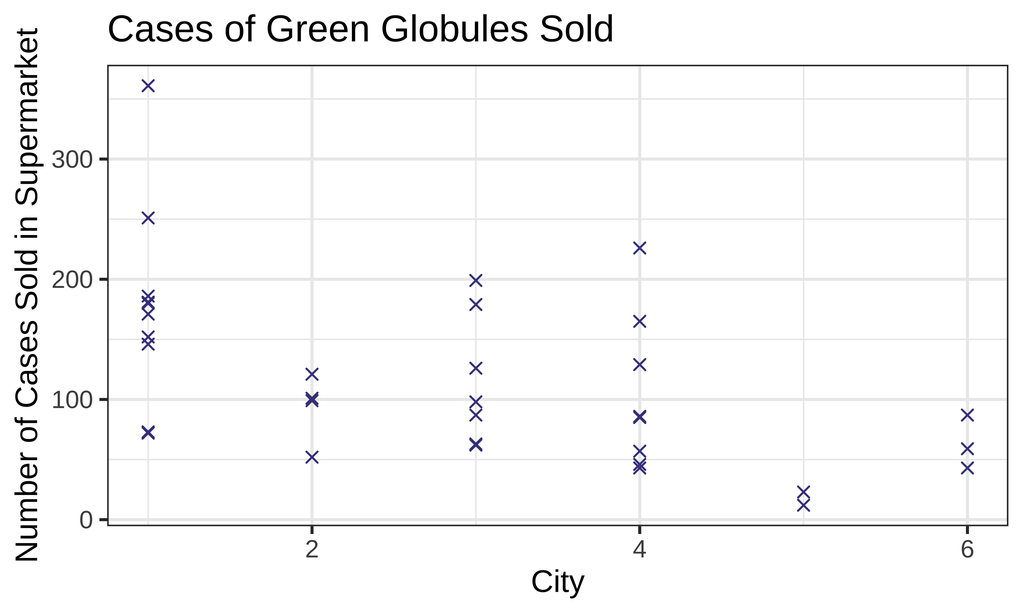

## Example (*Lohr* 5.8.7)

> Estimate the total number of cases sold and the standard error of the estimate.

$$\begin{align*}
\hat{t}_\text{unb} &= \frac{N}{n}\sum_{i\in\mathcal{S}}\hat{t}_i \\
\hat{V}(\hat{t}_\text{unb}) &= N^2\left(1-\frac{n}{N}\right)\frac{s_t^2}{n} + \frac{N}{n}\sum_{i\in\mathcal{S}}\left(1-\frac{m_i}{M_i}\right)M_i^2\frac{s_i^2}{m_i}
\end{align*}$$

## Example (*Lohr* 5.8.7)

> Estimate the total number of cases sold.

```r
N <- 45
n <- 6
Mi <- c(52,19,37,39,8,14)

t1.hat <- Mi[1]/mi[1] * sum(y1)
t2.hat <- Mi[2]/mi[2] * sum(y2)
t3.hat <- Mi[3]/mi[3] * sum(y3)
t4.hat <- Mi[4]/mi[4] * sum(y4)
t5.hat <- Mi[5]/mi[5] * sum(y5)
t6.hat <- Mi[6]/mi[6] * sum(y6)

ti.hat <- c(t1.hat, t2.hat, t3.hat, t4.hat, t5.hat, t6.hat)

#Total number of cases sold. M0 unknown -> unbiased estimator
t.hat <- (N/n) * sum(ti.hat)
t.hat
```

```
[1] 152972.2
```

## Example (*Lohr* 5.8.7)

> Find the standard error of the estimate for the total number of cases sold.

```r
st2 <- var(ti.hat)

s12 <- var(y1)
s22 <- var(y2)
s32 <- var(y3)
s42 <- var(y4)
s52 <- var(y5)
s62 <- var(y6)

si2 <- c(s12, s22, s32, s42, s52, s62)

se.t.hat <- sqrt(N^2*(1-n/N)*st2/n + (N/n)*sum((1-mi/Mi)*Mi^2*(si2/mi)))
se.t.hat
```

```
[1] 56781.08
```

## Example (*Lohr* 5.8.7)

Now, what if we wanted to estimate the *average* number of cases sold per store? We don’t know how many stores there are in the population, so we can use ratio estimation.

$$\begin{align*}
\hat{\bar{y}}_r &= \frac{\sum_{i\in\mathcal{S}} M_i\bar{y}_i}{\sum_{i\in\mathcal{S}} M_i} \\
\hat{V}(\hat{\bar{y}}_r) &= \frac{1}{\bar{M}^2}\left(1-\frac{n}{N}\right)\frac{s_r^2}{n} + \frac{1}{nN\bar{M}^2}\sum_{i\in\mathcal{S}}M_i^2\left(1-\frac{m_i}{M_i}\right)\frac{s_i^2}{m_i}
\end{align*}$$

## Example (*Lohr* 5.8.7)

> Find the average number of cases sold per store.

```r
# Estimate a mean. M0 unknown so use ratio estimation with Mi as auxiliary variable.

y.hat.bar <- sum(ti.hat) / sum(Mi)
y.hat.bar
```

```
[1] 120.6881
```

```r
    #variance of residuals. Not var(y.bar) !!!
sr2 <- sum((ti.hat - Mi*y.hat.bar)^2) / (n-1)

# si2 is the same as above

se.y.hat.bar <- sqrt(1/(mean(Mi)^2)*(1-n/N)*sr2/n +
                       1/(n*N*mean(Mi)^2)*sum(Mi^2*(1-mi/Mi)*si2/mi))
se.y.hat.bar
```

```
[1] 20.04893
```

## Sampling Weights

*Recall*: the sampling weight of unit $i$ is the number of population units represented by unit $i$.

In the weights we’ve looked at so far, we saw how to use the weights to calculate an estimate (for example, $\hat{t}$, $\bar{y}$).

## Quick Review

| Design/Estimator | Formula |
| --- | --- |
| SRS | $\hat{t}=\sum_{i\in\mathcal{S}} w_iy_i$ |
| Stratified | $\hat{t}_\text{str}=\sum_{h=1}^H\sum_{j\in\mathcal{S}_h}w_{hj}y_{hj}$ |
| Ratio | $\hat{t}_{yr}=w_ig_iy_i$ where $g_i=\frac{t_x}{\hat{t}_x}$ are weight calibrations |

## Weights in One-Stage Cluster Sampling

In a *one-stage cluster sample* with a SRS of psus, the weight for each observation unit is
$$w_{ij}=\frac{1}{P(\text{ssu }j\text{ of psu }i\text{ is in sample})}=\frac{1}{\frac{n}{N}}=\frac{N}{n}$$

This is a self-weighting sample.

The estimators can be written in terms of weights:

$$\begin{align*}
\hat{t}&=\sum_{i\in\mathcal{S}}\sum_{j\in\mathcal{S}_i}w_{ij}y_{ij} \\
\hat{\bar{y}} &= \frac{\sum_{i\in\mathcal{S}}\sum_{j\in\mathcal{S}_i}w_{ij}y_{ij}}{\sum_{i\in\mathcal{S}}\sum_{j\in\mathcal{S}_i}w_{ij}}
\end{align*}$$

## Weights in Two-Stage Cluster Sampling

For a *two-stage cluster sample* with a SRS of psus and a SRS of ssus within selected psus, the inclusion probability is

$$\begin{align*}
P(&j\text{th ssu in }i\text{th psu is selected}) \\
&= P(i\text{th psu selected}) \times P(j\text{th ssu selected | }i\text{th psu selected}) \\
&= \frac{n}{N}\frac{m_i}{M_i}
\end{align*}$$

So
$$w_{ij}=\frac{NM_i}{nm_i} \qquad \qquad \qquad \hat{t}_\text{unb}=\sum_{i\in\mathcal{S}}\sum_{j\in\mathcal{S}_i}w_{ij}y_{ij}$$

## Weights in Cluster Sampling

In a one-stage cluster sample, all ssus have the same weight ( $N/n$ ).

In a two-stage sample, all ssus have the same weight *only if* all $m_i/M_i$ are constant (sample same proportion from each cluster).

## Weights in Cluster Sampling

So we’ve seen how to calculate an estimator using sampling weights. But not the variances! *Why?*

We need to know the *joint inclusion probability* - that is, the probability that both unit $i$ and unit $k$ are in the sample.

*Example*: SRS and one-stage cluster sample have same weights (first-order inclusion probabilities), so you get the same estimator. But they have different variances. The probability that two units will be selected in the same sample will be different for the two designs. In a one-stage cluster sample, units in the same cluster will always be in the sample together. Not true for two SRS units.

# Lecture 2

## Outline

- Designing a Cluster Sample
- Examples
  - *Lohr* Example 5.10
  - *Lohr* Problem 5.8.22
- Systematic Sampling

## Homogeneity Within Clusters

Recall:
$$ICC = 1-\frac{M}{M-1}\frac{SSW}{SST}$$
**Intraclass Correlation** (**ICC**) is usually positive for naturally occurring clusters, and when the ICC is positive, cluster sampling is less efficient than SRS.

ICC is only defined for clusters of *equal* sizes. An alternative measure of homogeneity in general populations is $R_a^2$, the adjusted $R^2$:
$$R_a^2=1-\frac{MSW}{S^2}$$

## Designing a Cluster Sample

Exploratory questions:

- How much does it cost to sample a psu?
- How much does it cost to sample a ssu?
- What is the homogeneity within a psu (ICC or $R_a^2$)

Design questions:

1. What overall precision is needed?
2. What size should the psus be?
3. How many ssus should be sampled in each psu selected for the sample?
4. How many psus should be sampled?

## Choosing Cluster (psu) Size

May be obvious based on natural clustering (farms, classrooms, etc).

For area surveys, may not be as clear (1 sq km? 2 sq km?). General principle: psus of larger size tend to have more variability.

Choice may depend on a pilot study to measure relative costs and variances with different psu sizes.

## Optimal Allocation in Cluster Sampling

Want smallest $V(\hat{t}_\text{unb})$ and smallest cost.

Given

$$\begin{align*}
N &= \text{# psus in population} \\
M &= \text{# ssus per psu (assume same-sized clusters)} \\
R_a^2 &= 1-\frac{\text{MSW}}{S^2} \qquad \text{(measure of homogeneity)} \\
c_1 &= \text{cost to sample one psu} \\
c_2 &= \text{cost to sample one ssu} \\
\end{align*}$$

(This is an idealized situation, but it will get an estimate in the right ballpark.)

## Optimal Allocation in Cluster Sampling

Simple cost function:
$$\text{total cost}=C=c_1n+c_2nm$$
where $c_1$ is the cost per psu (not including the cost of measuring the ssus) and $c_2$ is the cost of measuring each ssu.

Then we can minimize the variance for fixed $C$ and find

$$\begin{align*}
n_\text{opt} &= \frac{C}{c_1+c_2m_\text{opt}} \\
m_\text{opt} &= \sqrt{\frac{c_1M(N-1)(1-R_a^2)}{c_2(NM-1)R_a^2}}
\end{align*}$$

## Choosing the Number of ssus

For $N>>M$ (many more clusters than observations within clusters),
$$m_\text{opt}=\sqrt{\frac{c_1M(N-1)(1-R_a^2)}{c_2(NM-1)R_a^2}} \approx \sqrt{\frac{c_1 (1-R_a^2)}{c_2 R_a^2}}$$

If $R_a^2\approx1$ (clusters homogeneous), then $m_\text{opt}$ will be small.

If $R_a^2 \approx 0$ (variability within clusters large), then need large $m_\text{opt}$.

## Choosing the Number of psus

$$n_\text{opt} = \frac{C}{c_1+c_2m_\text{opt}}$$

This means given $m_\text{opt}$, sample as many clusters as you can afford.

## Optimal Allocation with Unequal Cluster Sizes

If not all $M_i=M$ are the same, can use the previous formula with $\bar{M}$ (average cluster size) in place of $M$.

Then either take $m_\text{opt}$ ssus per cluster or sample proportional to cluster size.

## *Lohr* Example 5.10

This example looks at the Colorado potato beetle, a pest. Pilot study:

- Randomly select 10 sites.
- Investigators visit sites, count adult beetles on all foliage from a single stem on up to 5 adjacent plants.
- Consider designs with varying numbers of plants per site (1-5).
- It takes 30 minutes to walk all the sites, 10 seconds to examine a stem.

For a design where they look at one stem per site, what would be the total cost?

$$C=c_1n + c_2nm=\frac{30}{10}(10) + (1/6)*(10)*1=31.67 \text{ minutes}$$

For a design where they look at three stems per site, what would be the total cost?

$$C=c_1n + c_2nm=\frac{30}{10}(10) + (1/6)*(10)*3=35 \text{ minutes}$$

## *Lohr* Example 5.10

| Number of Stems Sampled Per Site | $\hat{\bar{y}}$ | $SE(\hat{\bar{y}})$ | Cost to Sample One Field | Relative Net Precision |
| --- | --- | --- | --- | --- |
| 1 | 1.12 | 0.15 | 31.67 | 0.24 |
| 2 | 1.01 | 0.10 | 33.33 | 0.30 |
| 3 | 0.96 | 0.08 | 35.00 | 0.34 |
| 4 | 0.91 | 0.07 | 36.67 | 0.35 |
| 5 | 0.91 | 0.06 | 38.33 | 0.40 |

Because the cost to sample additional stems is so cheap (10 seconds) relative to to cost to visit the clusters (30 minutes), sampling 5 stems per site is the most efficient.

## *Lohr* 5.8.22

This problem uses the `agsrs.csv` file you’ve used for homework a few times. Suppose $c_1=15c_2$, where $c_1$ is the cost to sample a state and $c_2$ is the cost to sample a county within a state. You want to sample 300 counties.

> What should $\bar{m}$ be?

First, you estimate $R_a^2$ from the data to be 0.5 (see code).

```r
library(SDAResources)
data(agsrs)

# get the adjusted R-squared
mod <- lm(acres92 ~ state, data=agsrs)
summary(mod)$adj.r.squared
```

```
[1] 0.4953455
```

## *Lohr* 5.8.22

Then, assuming $\frac{M(N-1)}{NM-1}\approx 1$,

$$\begin{align*}
\bar{m}_\text{opt} &= \sqrt{\frac{c_1 (1-R_a^2)}{c_2 R_a^2}} \\
&= \sqrt{\frac{15c_2(1-0.5)}{c_2(0.5)}} \\
&= \sqrt{15} \\
&= 3.9
\end{align*}$$

This means we should sample 3.9 counties per state on average.

## *Lohr* 5.8.22

> How many states would be sampled? (i.e., what is $n$)?

$\bar{m}_\text{opt}=3.9$, so round to 4.

Then 300/4 = 75 states. (!)

## Example Visualization

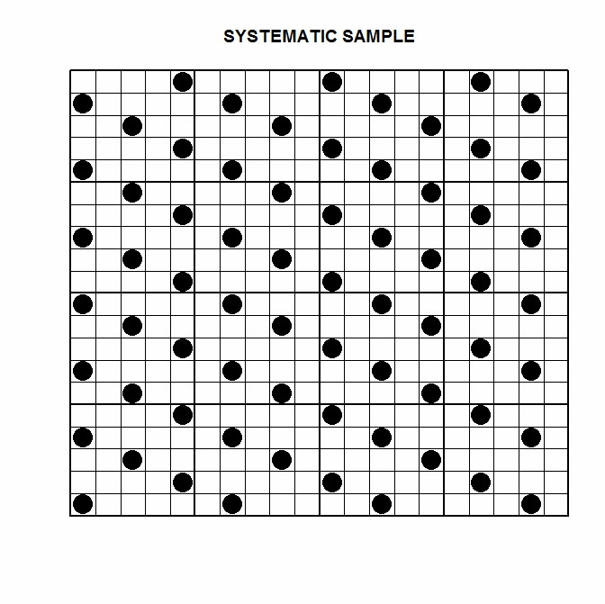

## Systematic Sampling Procedure (*Lohr* Sections 2.8, 5.5)

**Systematic sampling** is actually a special case of cluster sampling.

To obtain a systematic sample (SRS notation):

1. Choose a sample size $n$
2. If $N/n$ is an integer, let $k=N/n$; if not, let $k=N/n$ rounded up
3. Find a random integer $R$ between 1 and $k$
4. Then the units in the sample are those numbered $R$, $R+k$, $R+2k$, etc.

## Systematic Sampling

This gives a sample like a SRS *if* the units are in random order.

Example: list of students sorted by randomly generated student ID numbers.

However, the sample may not be representative if the listing of population units is in some periodic or cyclical order.

A systematic sample is not *actually* a SRS though, since not all possible groups of $n$ units have the same probability of being in the sample (e.g. two successive units will not be sampled together).

> Systematic sampling is actually a form of cluster sampling.

## Small Example

Suppose we want to take a systematic sample of size 3 from a population with 12 units:
$$1 \,\, 2 \,\, 3 \,\, 4 \,\, 5 \,\, 6 \,\, 7 \,\, 8 \,\, 9 \,\, 10 \,\, 11 \,\, 12$$

In this case $n=3$ and $k=N/n=12/3=4$.

To draw the systematic sample, we would randomly choose a number between 1 and 4, and then sample that unit along with every fourth element after.

The population then consists of four psus:
$$\{1,5,9\} \qquad \{2,6,10\} \qquad \{3,7,11\} \qquad \{4,8,12\}$$
We take a SRS of one psu. This is a one-stage cluster sample with $N=4$, $n=1$, $M=3$.

## Systematic Sampling as Cluster Sampling

For the selected psu, we observe its mean exactly. Therefore,

$$\hat{\bar{y}}_\text{sys}=\bar{y}_i=\bar{y}_{i\mathcal{U}}$$

This is an unbiased estimate of $\bar{y}_\mathcal{U}$ if $N/n$ is an integer (all clusters will be of equal size).

But $n=1$ so how do we estimate $\hat{V}(\hat{\bar{y}}_\text{sys})$?

## Variance for Systematic Sampling Estimators

1. If the list is in *random* order: use the SRS variance
   $$\hat{V}(\hat{\bar{y}}_\text{sys})= \left(1-\frac{M}{NM}\right)\frac{\text{sample var}}{M}$$
   where sample var $=\frac{1}{M-1}\sum_{i\in\mathcal{S}}(y_i-\hat{\bar{y}}_\text{sys})^2$
2. If the sampling frame is in *increasing* or *decreasing* order (**autocorrelated**): systematic sampling is more precise than SRS; use the SRS variance, knowing that it will likely be too large and CIs likely too wide
3. If the sampling frame has a *periodic* pattern: dangerous! Systematic sampling is less precise than SRS

## Example of Random Order

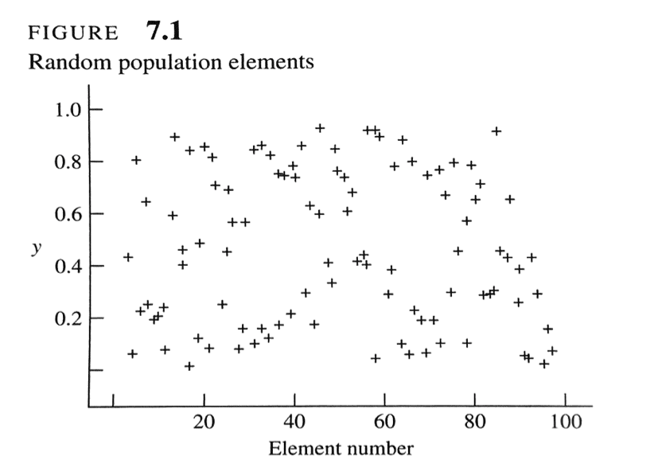

(From *Elementary Survey Sampling*, Scheaffer, Mendenhall, and Ott)

## Example of Increasing Pattern

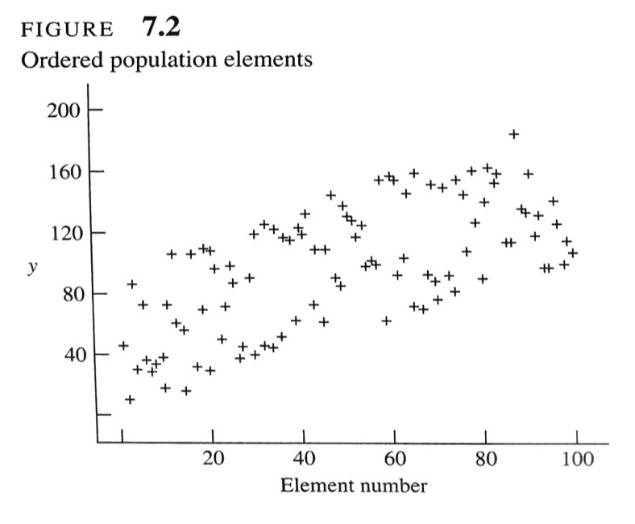

100 elements are shown along with x-axis, with y-values between 0 and 200. The points appear to form a quadrilateral with positive slope.

(From *Elementary Survey Sampling*, Scheaffer, Mendenhall, and Ott)

## Example of Periodic Pattern

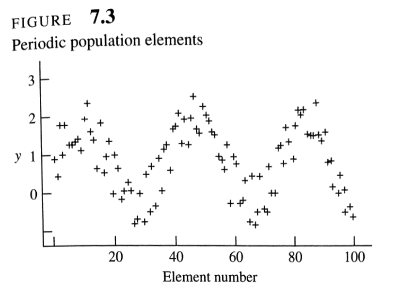

100 elements are shown along with x-axis, with y-values between -1 and 3. The points appear to closely follow a sinusoidal shape with horizontal axis around 1. There are a little more than two complete waves shown.

(From *Elementary Survey Sampling*, Scheaffer, Mendenhall, and Ott)

## When to Use Systematic Sampling

Often used when a researcher wants a representative sample of the population, but does not have the resources to construct a sampling frame in advance.

There may also be situations where it is important to have even (spatial) coverage of an area.

## Example (*Lohr* 5.8.24)

Hourly ozone readings from a site in Monterey County, California for 2018 and 2019. There are 17520 readings (with 60 missing values - ignore for now). Take a systematic sample with period 24. These data are called `ozone` in the `SDAResources` package in R.

Randomly sample an integer from 1 to 24. Let’s say I got 8 (which corresponds to hour 7). Observe units 8, 32, 56, $\ldots$

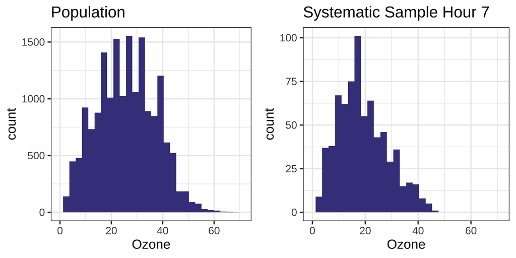

## Example (*Lohr* 5.8.24)

Treat the systematic sample as a SRS.

> Find the sample mean, and estimate a 95% confidence interval of the population mean.

$$\begin{align*}
\hat{\bar{y}}_\text{sys} &= \bar{y}_i = 19.08 \\
\text{SE}(\hat{\bar{y}}_\text{sys}) &= \sqrt{\left(1-\frac{n}{N}\right)\frac{s^2}{n}} = 0.3380 \\
\end{align*}$$

A 95% confidence interval is $[18.42, 19.74]$.

(Calculations on next slide)

## Example (*Lohr* 5.8.24)

```r
library(SDAResources)
N <- 17520 - 60
n <- length(na.omit(ozone$hr7))
(pt.est <- mean(ozone$hr7, na.rm=TRUE))
```

```
[1] 19.08104
```

```r
(se <- sqrt((1-n/N) * var(ozone$hr7, na.rm=TRUE) / n))
```

```
[1] 0.3379548
```

```r
pt.est + c(-1,1) * 1.96 * se
```

```
[1] 18.41865 19.74344
```

## Example (*Lohr* 5.8.24)

Let’s compare to the true population mean.

```r
all <- unlist(ozone[,4:27])
mean(all, na.rm=TRUE)
```

```
[1] 25.7819
```

The true population mean was 25.78, which is not in our CI!! What happened? The sample size was 728, so this doesn’t seem to be an issue.

## Example (*Lohr* 5.8.24)

Periodic effect of hourly ozone! This is because we used $k=24$.

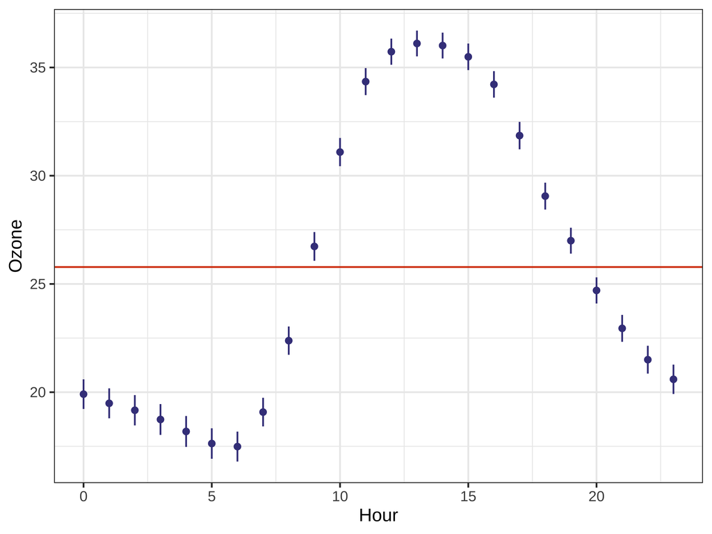